# Testing in R

Daniel Chen

April 8, 2016

# Hi!

# I’m Daniel

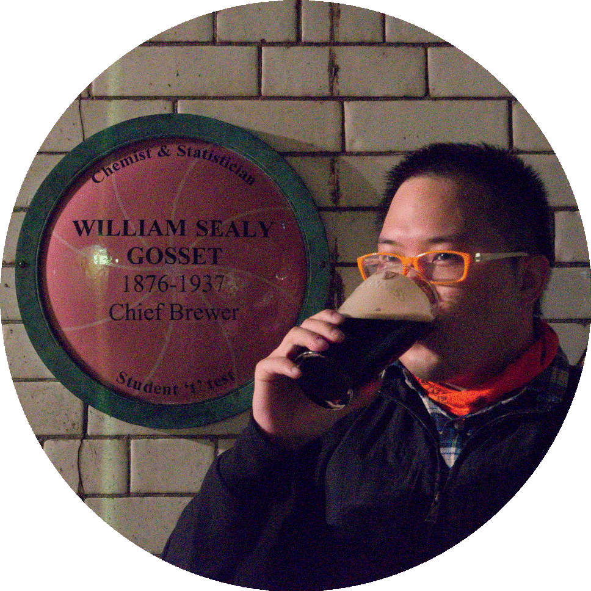

- “Guniness beer in your belly.” - Julia, my sister

# Who am I?

- Graduate Student @ Virginia Tech
  - Social and Decision Analytics Laboratory
  - Network Dynamics and Simulation Science Laboratory
- Software/Data Carpentry Instructor
  - R Inflammation-Lesson Maintainer
- Arch User Repository (AUR) maintainer for  
  `rstudio-desktop-preview-bin`
- Data Scientist @ Lander Analytics

# This talk

- is about testing

# What do you test?

- Anything
- Everything
- Functions
- Data
- scripts

# tl;dr

- `RUnit` - Roman Zenka
- `testthat` - Hadley Wickham
- `datacheck` Reinhard Simon
- `validate` - Mark van der Loo

# Testing Functions

# Testing Functions

Define a temperature conversion function.

```r
# convert Fahrenheit to Kelvin
f_k <- function(temp){
    ((temp - 32)) * floor(5/9) + 273.15
}
```

# Testing Functions

```r
f_k(32)
```

```
## [1] 273.15
```

# Testing Functions

```r
f_k(212)
```

```
## [1] 273.15
```

# What went wrong?

```r
# convert Fahrenheit to Kelvin
f_k <- function(temp){
    ((temp - 32)) * floor(5/9) + 273.15
}
```

```r
# convert Fahrenheit to Kelvin, correctly
f_k <- function(temp){
    ((temp - 32)) * (5/9) + 273.15
}
```

```r
print(sprintf("%f, %f", f_k(32), f_k(212)))
```

```
## [1] "273.150000, 373.150000"
```